# Project 2 Doc

Created by: David Tran, Juliette Seive, Boris Boukhonine

*“Catches of fish, crustaceans, molluscs and other aquatic organisms are reported in whole tonnes live weight (TLW) per species, fishing area, country and year.”*

**Countries Key**

Code Country BG Bulgaria ES Spain DK Denmark DE Germany BE Belgium IE Ireland EE Estonia FR France IT Italy LV Latvia LT Lithuania NL Netherlands PL Poland PT Portugal RO Romania FI Finland SE Sweden UK United Kingdom (E+W+S+NI) UKM Scotland IS Iceland NO Norway FO Faeroe Islands (DK) GG Guernsey IM Isle of Man JE Jersey RU Russia SJ Svalbard and Jan Mayen UA Ukraine LY Libya CV Cape Verde GL Greenland (DK) US United States PA Panama CN China (including Hong Kong) JP Japan KR South Korea TW Taiwan OUT Outbound

**Plots are as follows**  
1) Total fish weights by species per country for 2013

2. Counted fish weights for various species from 2007 to 2013 for France Filtered out all weight below 10000 tons.
3. Comparison of France and Spain over years Filtered out all weights below 10000 tons

**Load packages and fetch data**

```r
source("../01 Data/package_loader.R", echo = TRUE)
```

```
##
## > library("RCurl")
```

```
##
## > library("ggplot2")
##
## > library("dplyr")
```

```
##
## > library("tidyr")
```

```r
source("../01 Data/dataframe.R", echo=TRUE)
```

```
##
## > df <- data.frame(eval(parse(text = substring(getURL(URLencode("http://129.152.144.84:5001/rest/native/?query=\"select * from catches\""),
## +     htt .... [TRUNCATED]
##
## > df %>% tbl_df
## Source: local data frame [48,729 x 12]
##
##    SPECIES      AREA UNITS COUNTRY Y2013 Y2012 Y2011 Y2010 Y2009 Y2008
## 1      ALV    27_8_D   TLW      IE     0     0     0     0     0     0
## 2      ALV    27_8_D   TLW      PT     0     0     0     1     2     0
## 3      ALV  27_8_D_1   TLW      ES     0     0     0     0     7     0
## 4      ALV 27_8_D_NK   TLW      ES     0     0     0     0     0     5
## 5      ALV 27_8_D_NK   TLW      FR     1     0     0     0     2     1
## 6      ALV 27_8_D_NK   TLW      IE     0     0     0     0     0     0
## 7      ALV 27_8_D_NK   TLW      PT     0     0     0     1     2     0
## 8      ALV    27_8_E   TLW      FR     0     0     0     0     0     0
## 9      ALV    27_8_E   TLW      PT     0     0     0     0     0     0
## 10     ALV 27_8_E_NK   TLW      FR     0     0     0     0     0     0
## ..     ...       ...   ...     ...   ...   ...   ...   ...   ...   ...
## Variables not shown: Y2007 (dbl), Y2006 (dbl)
```

**Wrangle the data**

```r
source("../02 Data_Wrangling/wrangling.R", echo=TRUE)
```

```
##
## > df %>% select(SPECIES, COUNTRY, Y2013) %>% filter(Y2013 >=
## +     10000) %>% group_by(SPECIES) %>% ggplot(aes(x = COUNTRY,
## +     y = Y2013, color = .... [TRUNCATED]
```

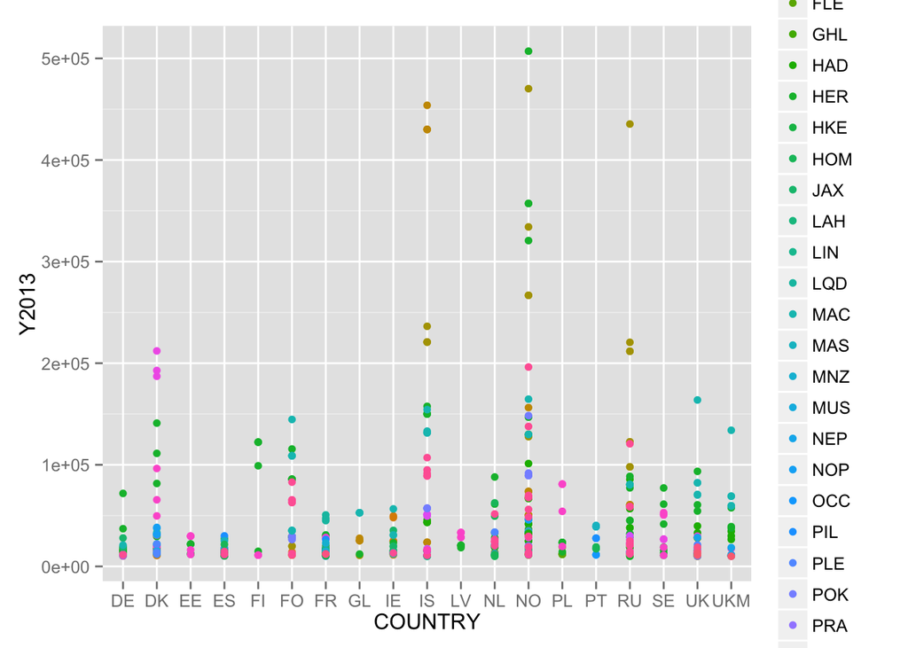

```
##
## > alt <- df %>% select(SPECIES, COUNTRY, Y2013, Y2012,
## +     Y2011, Y2010, Y2009, Y2008, Y2007) %>% gather("YEAR", "WEIGHT",
## +     3:9)
##
## > alt %>% filter(COUNTRY == "FR" & WEIGHT >= 10000) %>%
## +     ggplot(aes(x = SPECIES, y = WEIGHT)) + geom_point() + facet_wrap(~YEAR)
```

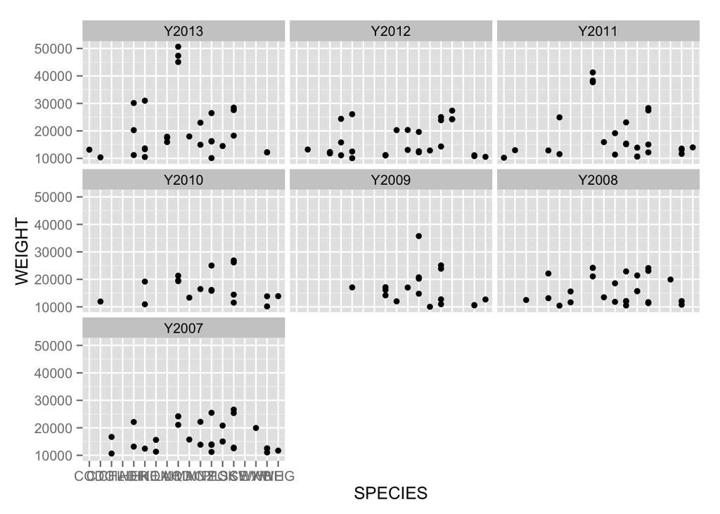

```
##
## > alt %>% filter(COUNTRY %in% c("ES", "FR") & WEIGHT >
## +     10000) %>% ggplot(aes(x = SPECIES, y = WEIGHT, color = COUNTRY)) +
## +     geom_point() + .... [TRUNCATED]
```

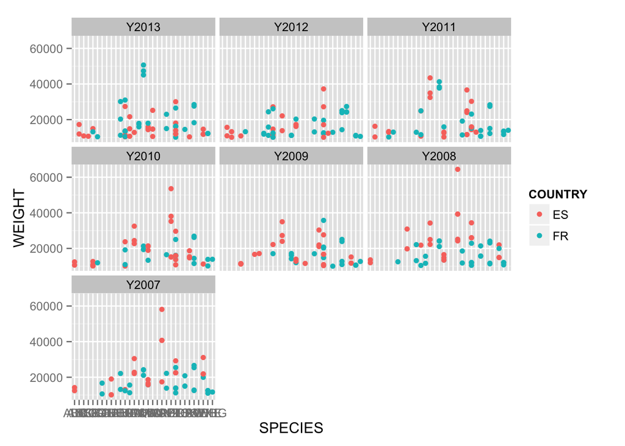